# STAT 385 HW7

# Introduction

The project seeks to explore the enactment California Consumer Privacy Act (CCPA)’s short term effect on venture investment activities. The data set contains informations of all venture investment activities from june 28th, 2017 to June 28th, 2019 in california and massachusetts. The data come from three groups of industries: finance, health care and information technology.

# Questions

- How are funding types distributed among industry groups?
- How are funding status distributed among industry groups?
- How are money raised distributed among industry groups?
- How is the trend of trading events progress overtime?
- How is the trend of money raised progress overtime?

```r
#install.packages("dplyr")
#install.packages("ggplot2")
#install.packages("xts")
#install.packages("zoo")
#install.packages("tidyverse")
#install.packages("lubridate")
#install.packages("gridExtra")
library(tidyverse)
library(lubridate)
library(dplyr)
library(ggplot2)
library(xts)
library(zoo)
library(gridExtra)
```

# Datacleaning

## (California)

```r
funding_rounds_cal = read.csv("/cloud/project/funding-rounds-4-20-2020.csv")
funding_rounds_cal_2 = read.csv("/cloud/project/funding-rounds-4-20-2020 (1).csv")
funding_rounds_cal_3 = read.csv("/cloud/project/funding-rounds-4-20-2020 (2).csv")
funding_rounds_cal_4= read.csv("/cloud/project/funding-rounds-4-20-2020 (3).csv")

funding_rounds_cal_comb = unique(rbind(funding_rounds_cal, funding_rounds_cal_2, funding_rounds_cal_3, funding_rounds_cal_4))

x_zoo = as.xts(funding_rounds_cal_comb[,"Money.Raised"], order.by=as.Date(funding_rounds_cal_comb$Announced.Date))
# covert to xts form to add time stamp

weekly_funding_agg = apply.weekly(x_zoo,sum,na.rm=TRUE)
weekly_dealings_agg = apply.weekly(x_zoo,nrow)
# group by weeks and get the aggregate sum of money & number of dealings

funding_rounds_cal_agg = as.data.frame(cbind(weekly_funding_agg, weekly_dealings_agg))
funding_rounds_cal_agg$Treatment = 1
funding_rounds_cal_agg$week = 1:nrow(funding_rounds_cal_agg)
funding_rounds_cal_agg =funding_rounds_cal_agg[,c("week","weekly_funding_agg","weekly_dealings_agg","Treatment")]
colnames(funding_rounds_cal_agg) = c("week", "Raised_total", "occurance","Treatment")
funding_rounds_cal_agg[c(1:53),"post"] = 0
funding_rounds_cal_agg[c(54:nrow(funding_rounds_cal_agg)),"post"] = 1
# combine dataframe
```

```r
Fin_rows = grep("Finance|FinTech|FinacialService", funding_rounds_cal_comb$Organization.Industries)
funding_rounds_cal_comb[Fin_rows, "Industries_Level"]="Finance"
Health_rows = grep("Health Care", funding_rounds_cal_comb$Organization.Industries)
funding_rounds_cal_comb[Health_rows, "Industries_Level"]="Health Care"
Info_rows = grep("Information Technology", funding_rounds_cal_comb$Organization.Industries)
funding_rounds_cal_comb[Info_rows, "Industries_Level"]="Info Tech"
```

```r
quant = as.numeric(quantile(funding_rounds_cal_comb$Money.Raised, na.rm = T))

q1 = which(funding_rounds_cal_comb$Money.Raised>quant[1] & funding_rounds_cal_comb$Money.Raised<=quant[2])
q2 = which(funding_rounds_cal_comb$Money.Raised>quant[2] & funding_rounds_cal_comb$Money.Raised<=quant[3])
q3 = which(funding_rounds_cal_comb$Money.Raised>quant[3] & funding_rounds_cal_comb$Money.Raised<=quant[4])
q4 = which(funding_rounds_cal_comb$Money.Raised>quant[4] & funding_rounds_cal_comb$Money.Raised<=quant[5])
funding_rounds_cal_comb[q1,"Money.Raised.Levels"]="$1000-$1M"
funding_rounds_cal_comb[q2,"Money.Raised.Levels"]="$1M-$5M"
funding_rounds_cal_comb[q3,"Money.Raised.Levels"]="$5M-$17.5M"
funding_rounds_cal_comb[q4,"Money.Raised.Levels"]="$17.5M-$2B"
```

## (Massachusetts)

```r
funding_rounds_mass = read.csv("/cloud/project/funding-rounds-4-20-2020 (4).csv")
#funding_rounds_mass_2 = read.csv("/cloud/project/funding-rounds-massachusetts-2.csv")

funding_rounds_mass_comb = unique(funding_rounds_mass)
attach(funding_rounds_mass_comb)

x_zoo = as.xts(funding_rounds_mass_comb[,"Money.Raised"], order.by=as.Date(funding_rounds_mass_comb$Announced.Date))
# covert to xts form to add time stamp

weekly_funding_agg = apply.weekly(x_zoo,sum,na.rm=TRUE)
weekly_dealings_agg = apply.weekly(x_zoo,nrow)
# group by weeks and get the aggregate sum of money & number of dealings

funding_rounds_mass_agg = as.data.frame(cbind(weekly_funding_agg, weekly_dealings_agg))
funding_rounds_mass_agg$Treatment = 0
funding_rounds_mass_agg$week = 1:nrow(funding_rounds_mass_agg)
funding_rounds_mass_agg =funding_rounds_mass_agg[,c("week","weekly_funding_agg","weekly_dealings_agg","Treatment")]
colnames(funding_rounds_mass_agg) = c("week", "Raised_total", "occurance","Treatment")
funding_rounds_mass_agg[c(1:53),"post"] = 0
funding_rounds_mass_agg[c(53:nrow(funding_rounds_mass_agg)),"post"] = 1
# combine dataframe
```

```r
funding_rounds_agg_comb = rbind(funding_rounds_cal_agg, funding_rounds_mass_agg)
```

# Graphs

## Q1 Distribution of Funding Type from Different Industries

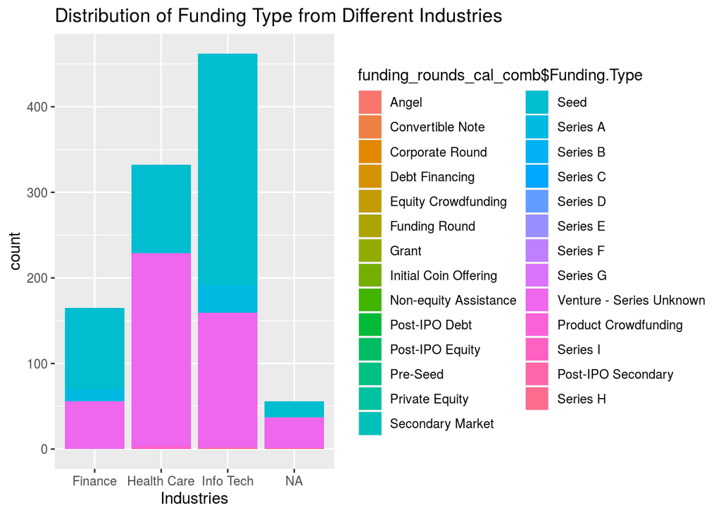

```r
q1.1 <- ggplot(data = funding_rounds_cal_comb) +
  geom_bar(mapping = aes(x = funding_rounds_cal_comb$Industries_Level, fill = funding_rounds_cal_comb$Funding.Type), position = "identity") +
  labs(title="Distribution of Funding Type from Different Industries", x="Industries", colour="Funding Type")
q1.1
```

## Q2 Distribution of Funding Status from Different Industries

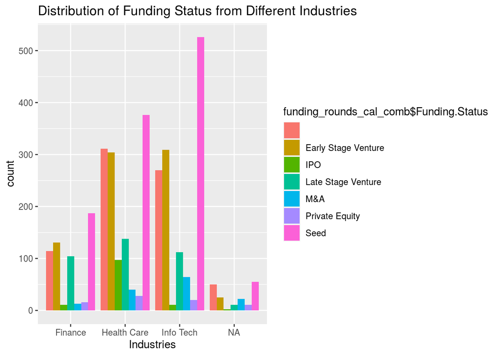

```r
q2.1 <- ggplot(data = funding_rounds_cal_comb) +
  geom_bar(mapping = aes(x = funding_rounds_cal_comb$Industries_Level, fill = funding_rounds_cal_comb$Funding.Status), position = "dodge")+
  labs(title="Distribution of Funding Status from Different Industries", x="Industries", colour="Funding Type")
q2.1
```

Seed stage venture activities occurred the most among industries while private equity, M&A and IPO occur least among three industries.

## Q3 Distribution of Raised Money from Different Industries

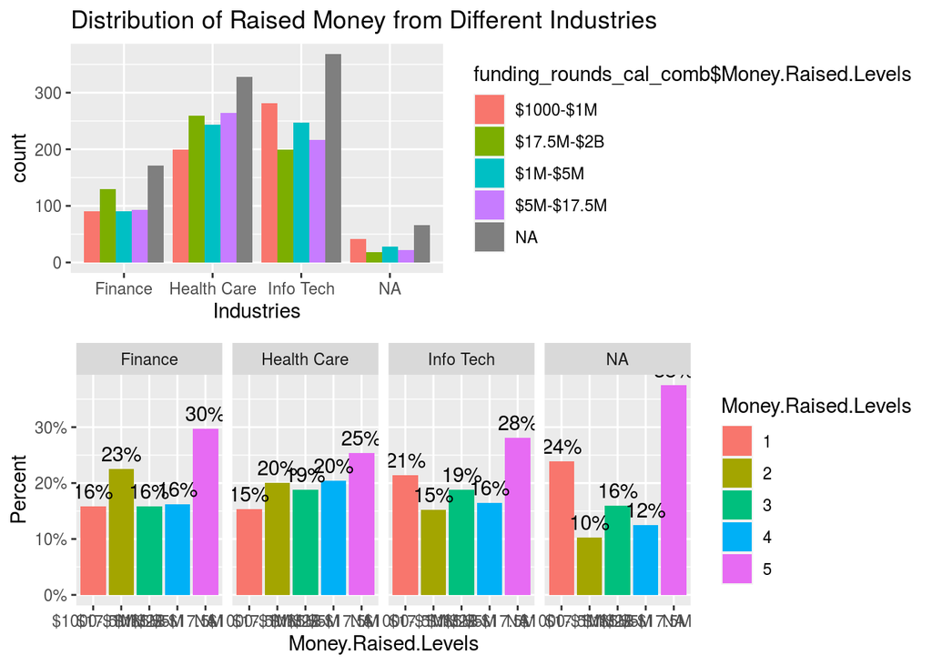

```r
q3.1 <- ggplot(data = funding_rounds_cal_comb) +
  geom_bar(mapping = aes(x = funding_rounds_cal_comb$Industries_Level, fill = funding_rounds_cal_comb$Money.Raised.Levels), position = "dodge") +
  labs(title="Distribution of Raised Money from Different Industries", x="Industries", colour="Funding Type")

q3.2 = ggplot(funding_rounds_cal_comb, aes(x=Money.Raised.Levels ,group=Industries_Level)) +
    geom_bar(aes(y = ..prop.., fill = factor(..x..)), stat="count") +
    geom_text(aes( label = scales::percent(..prop..),
                   y= ..prop.. ), stat= "count", vjust = -.5) +
    labs(y = "Percent", fill="Money.Raised.Levels") +
    facet_grid(~Industries_Level) +
    scale_y_continuous(labels = scales::percent)

grid.arrange(q3.1, q3.2, nrow = 2)
```

In finance industry, venture activities among $17.5M-$2B occurs the most while other range remain relatively the same. In health care industry, $5M-$17.5M occurs the most. In info tech industry, the $1000-$1M range occurs the most.

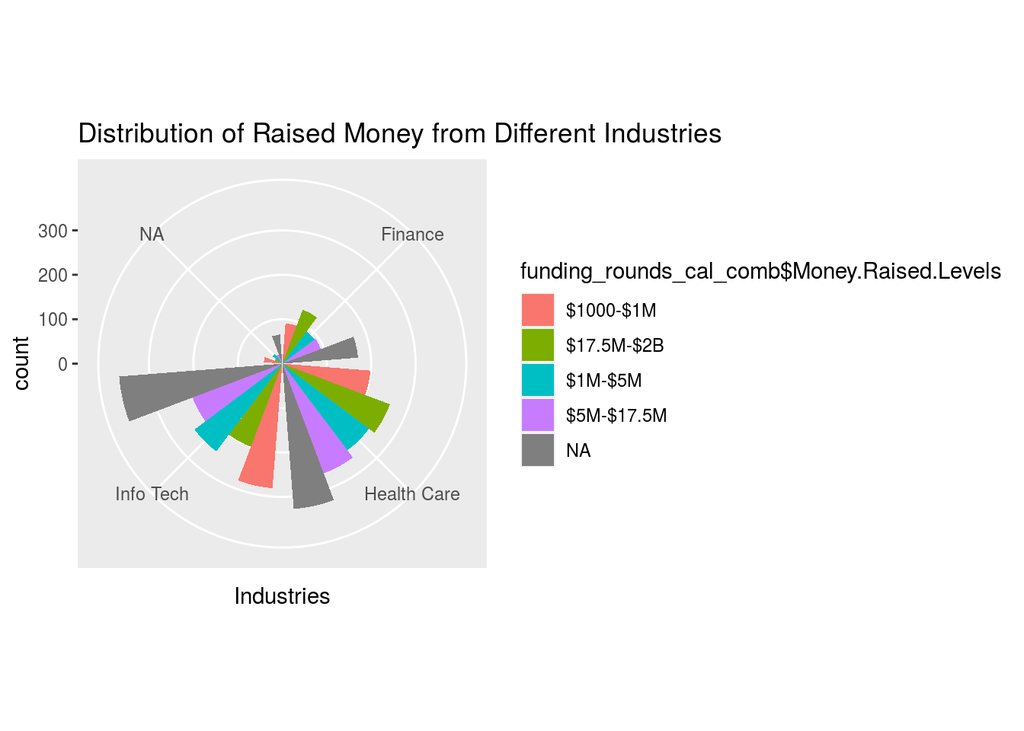

```r
q3.3 <- ggplot(data = funding_rounds_cal_comb) +
  geom_bar(mapping = aes(x = funding_rounds_cal_comb$Industries_Level, fill = funding_rounds_cal_comb$Money.Raised.Levels), position = "dodge") +
  labs(title="Distribution of Raised Money from Different Industries", x="Industries", colour="Funding Type")+
  coord_polar()
q3.3
```

## Q4 DIstribution of Money Raised Among Industries

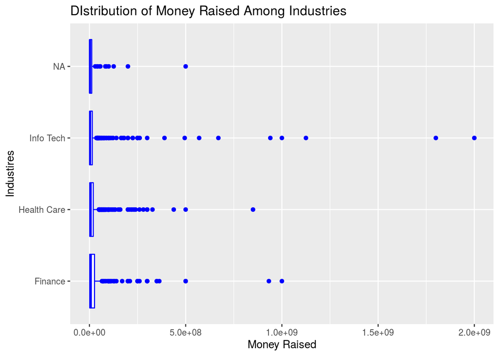

```r
q4 = ggplot(data = funding_rounds_cal_comb) +
  geom_boxplot(mapping = aes(x = Money.Raised, y = funding_rounds_cal_comb$Industries_Level), color="Blue") +
  labs(title = "DIstribution of Money Raised Among Industries", x="Money Raised", y="Industires")
q4
```

The distribution of money raised is mostly concentrated on lower end of the scale.

## Q5 Weekly Investment Events Over Time (Cal)

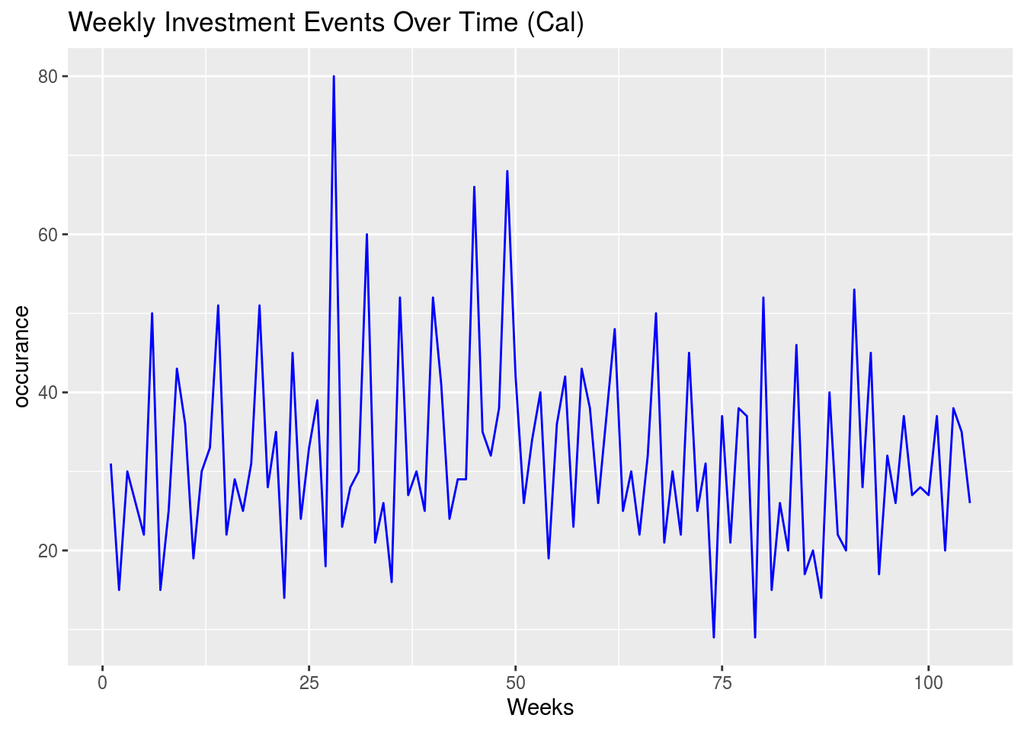

```r
cal_fundings_trend = ggplot(data = funding_rounds_cal_agg) +
  geom_freqpoly(mapping = aes(x = week, y = occurance), stat = "identity", color="blue") +
  labs(title="Weekly Investment Events Over Time (Cal)", x="Weeks")
cal_fundings_trend
```

## Weekly Investment Events Overtime (Mass)

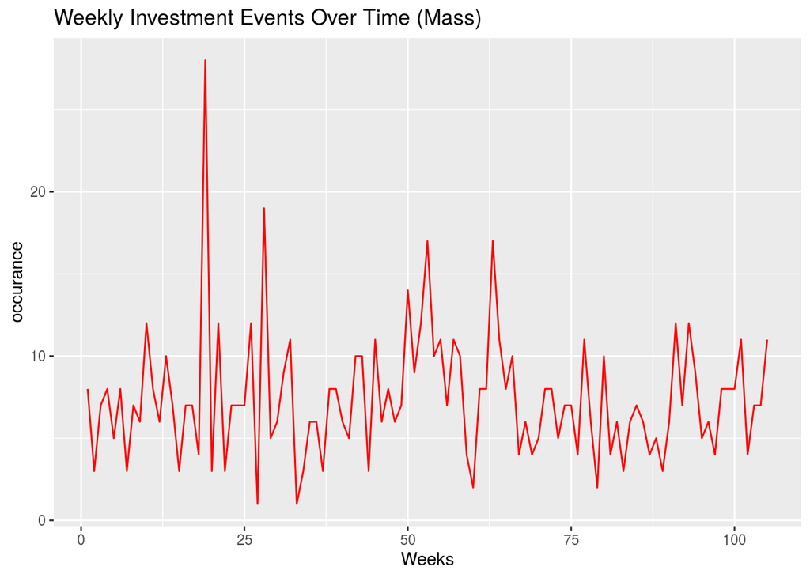

```r
mass_fundings_trend = ggplot(data = funding_rounds_mass_agg) +
  geom_freqpoly(mapping = aes(x = week, y = occurance), stat = "identity", color="red") +
  labs(title="Weekly Investment Events Over Time (Mass)", x="Weeks")
mass_fundings_trend
```

The venture investment activities of massachusettes remain relatively unchanged as it is out of the sovereighty of CCPA.

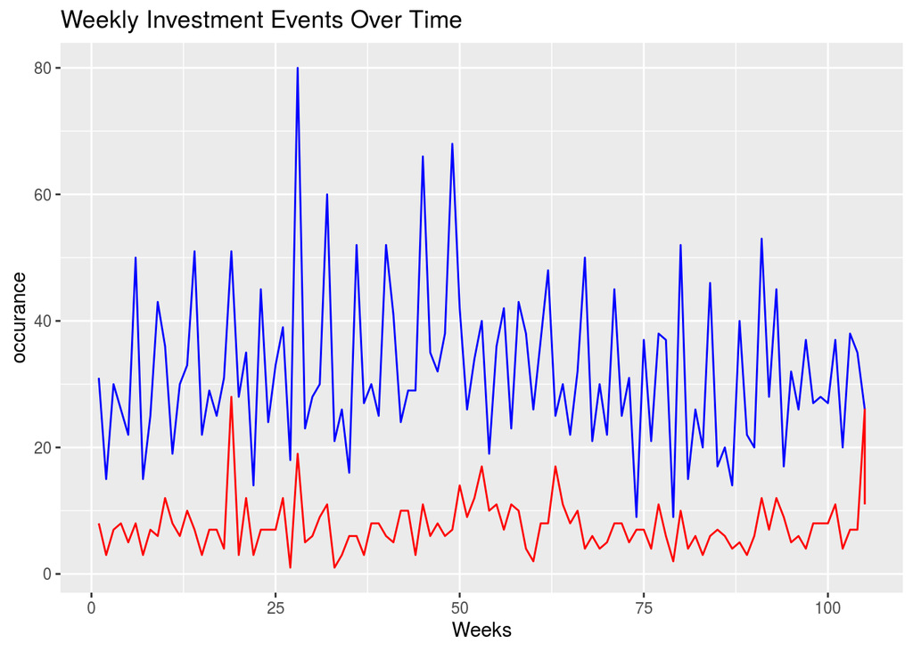

```r
ggplot() +
  geom_line(data = funding_rounds_agg_comb[1:105,], mapping = aes(x = week, y = occurance), stat = "identity", color="blue")+ geom_line(data = funding_rounds_agg_comb[105:210,],mapping = aes(x = week, y = occurance), stat = "identity", color="red")+
  labs(title="Weekly Investment Events Over Time", x="Weeks")
```

## Weekly Aggregated Money Raised (Cal)

[figure not shown]

```r
cal_fundings_trend = ggplot(data = funding_rounds_cal_agg) +
  geom_freqpoly(mapping = aes(x = week, y = Raised_total), stat = "identity", color="blue") +
  labs(title="Weekly Aggregated Money Raised (Mass)", y="Money Raised (Weekly)", x="Weeks")
cal_fundings_trend
```

There’s no obvious change in the trend of money raised for california. This is probably due to the fact that finance and health care industries, which take over half of the overall venture investment activities are less affected due to existing regulations.

## Weekly Aggregated Money Raised (Mass)

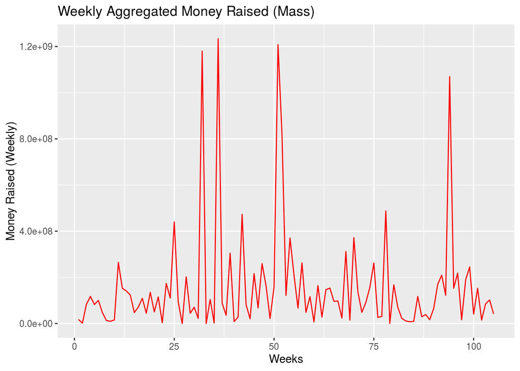

```r
mass_fundings_trend = ggplot(data = funding_rounds_mass_agg) +
  geom_freqpoly(mapping = aes(x = week, y = Raised_total), stat = "identity", color="red") +
  labs(title="Weekly Aggregated Money Raised (Mass)", y="Money Raised (Weekly)", x="Weeks")
mass_fundings_trend
```

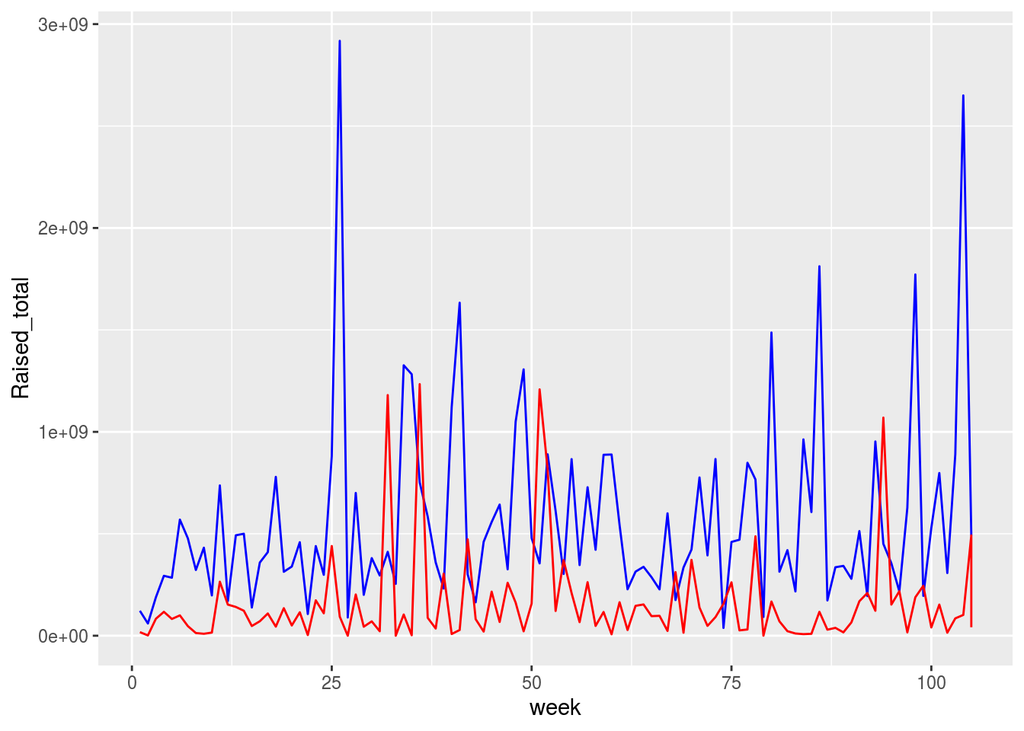

```r
ggplot() +
  geom_line(data = funding_rounds_agg_comb[1:105,], mapping = aes(x = week, y = Raised_total), stat = "identity", color="blue")+ geom_line(data = funding_rounds_agg_comb[105:210,],mapping = aes(x = week, y = Raised_total), stat = "identity", color="red")
```

# Regression

```r
attach(funding_rounds_agg_comb)
funding_rounds_agg_comb$did = post*Treatment
```

```r
#didreg = lm(occurance ~ Treatment + week + did)
#summary(didreg)
```

```r
didreg = lm(Raised_total ~ Treatment + week + did , data=funding_rounds_agg_comb)
summary(didreg)
```

```
##
## Call:
## lm(formula = Raised_total ~ Treatment + week + did, data = funding_rounds_agg_comb)
##
## Residuals:
##        Min         1Q     Median         3Q        Max
## -539010210 -195554413  -79239259   47100411 2371346922
##
## Coefficients:
##              Estimate Std. Error t value Pr(>|t|)
## (Intercept)  64807260   68296342   0.949    0.344
## Treatment   435887630   69510873   6.271 2.08e-09 ***
## week          1761068    1085666   1.622    0.106
## did         -53709748   93076447  -0.577    0.565
## ---
## Signif. codes:  0 '***' 0.001 '**' 0.01 '*' 0.05 '.' 0.1 ' ' 1
##
## Residual standard error: 3.77e+08 on 206 degrees of freedom
## Multiple R-squared:  0.2393, Adjusted R-squared:  0.2282
## F-statistic:  21.6 on 3 and 206 DF,  p-value: 3.337e-12
```